# INN_Learner_Notebook_Full_code_Mounika (1)

Bank Churn Prediction

## Problem Statement

### Context

Businesses like banks which provide service have to worry about problem of 'Customer Churn' i.e. customers leaving and joining another service provider. It is important to understand which aspects of the service influence a customer's decision in this regard. Management can concentrate efforts on improvement of service, keeping in mind these priorities.

### Objective

You as a Data scientist with the bank need to build a neural network based classifier that can determine whether a customer will leave the bank or not in the next 6 months.

### Data Dictionary

- CustomerId: Unique ID which is assigned to each customer
- Surname: Last name of the customer
- CreditScore: It defines the credit history of the customer.
- Geography: A customer’s location
- Gender: It defines the Gender of the customer
- Age: Age of the customer
- Tenure: Number of years for which the customer has been with the bank
- NumOfProducts: refers to the number of products that a customer has purchased through the bank.
- Balance: Account balance
- HasCrCard: It is a categorical variable which decides whether the customer has credit card or not.
- EstimatedSalary: Estimated salary
- isActiveMember: Is is a categorical variable which decides whether the customer is active member of the bank or not ( Active member in the sense, using bank products regularly, making transactions etc )
- Exited : whether or not the customer left the bank within six month. It can take two values **0=No ( Customer did not leave the bank )** 1=Yes ( Customer left the bank )

## Importing necessary libraries

```python
# Installing the libraries with the specified version.
!pip install tensorflow==2.17.0 scikit-learn==1.2.2 seaborn==0.13.1 matplotlib==3.7.1 numpy==1.26.0 pandas==2.1.4 imbalanced-learn==0.10.1 -q --user
```

```python
 # Libraries to help with reading and manipulating data
import pandas as pd
import numpy as np

# libaries to help with data visualization
import matplotlib.pyplot as plt
import seaborn as sns

# Library to split data
from sklearn.model_selection import train_test_split

# library to import to standardize the data
from sklearn.preprocessing import StandardScaler, LabelEncoder

# importing different functions to build models
import tensorflow as tf
from tensorflow import keras
from keras import backend
from keras.models import Sequential
from keras.layers import Dense, Dropout

# importing SMOTE
from imblearn.over_sampling import SMOTE

# importing metrics
from sklearn.metrics import confusion_matrix,roc_curve,classification_report,recall_score

import random

# Library to avoid the warnings
import warnings
warnings.filterwarnings("ignore")
```

## Loading the dataset

```python
from google.colab import drive
drive.mount('/content/drive/')
```

```python
data = pd.read_csv('/content/drive/MyDrive/Churn.csv')
```

## Data Overview

**View first 5 and last 5 rows of the dataset**

```python
# Let's validate first 5 rows of the data
data.head()
```

|  | RowNumber | CustomerId | Surname | CreditScore | Geography | Gender | Age | Tenure | Balance | NumOfProducts | HasCrCard | IsActiveMember | EstimatedSalary | Exited |
| --- | --- | --- | --- | --- | --- | --- | --- | --- | --- | --- | --- | --- | --- | --- |
| 0 | 1 | 15634602 | Hargrave | 619 | France | Female | 42 | 2 | 0.00 | 1 | 1 | 1 | 101348.88 | 1 |
| 1 | 2 | 15647311 | Hill | 608 | Spain | Female | 41 | 1 | 83807.86 | 1 | 0 | 1 | 112542.58 | 0 |
| 2 | 3 | 15619304 | Onio | 502 | France | Female | 42 | 8 | 159660.80 | 3 | 1 | 0 | 113931.57 | 1 |
| 3 | 4 | 15701354 | Boni | 699 | France | Female | 39 | 1 | 0.00 | 2 | 0 | 0 | 93826.63 | 0 |
| 4 | 5 | 15737888 | Mitchell | 850 | Spain | Female | 43 | 2 | 125510.82 | 1 | 1 | 1 | 79084.10 | 0 |

```python
# Let's validate last 5 rows of the data
data.tail()
```

|  | RowNumber | CustomerId | Surname | CreditScore | Geography | Gender | Age | Tenure | Balance | NumOfProducts | HasCrCard | IsActiveMember | EstimatedSalary | Exited |
| --- | --- | --- | --- | --- | --- | --- | --- | --- | --- | --- | --- | --- | --- | --- |
| 9995 | 9996 | 15606229 | Obijiaku | 771 | France | Male | 39 | 5 | 0.00 | 2 | 1 | 0 | 96270.64 | 0 |
| 9996 | 9997 | 15569892 | Johnstone | 516 | France | Male | 35 | 10 | 57369.61 | 1 | 1 | 1 | 101699.77 | 0 |
| 9997 | 9998 | 15584532 | Liu | 709 | France | Female | 36 | 7 | 0.00 | 1 | 0 | 1 | 42085.58 | 1 |
| 9998 | 9999 | 15682355 | Sabbatini | 772 | Germany | Male | 42 | 3 | 75075.31 | 2 | 1 | 0 | 92888.52 | 1 |
| 9999 | 10000 | 15628319 | Walker | 792 | France | Female | 28 | 4 | 130142.79 | 1 | 1 | 0 | 38190.78 | 0 |

**Understand the Shape of the dataset**

```python
data.shape
```

```
(10000, 14)
```

Provided dataset has 10000 rows and 14 features

**Check the data types of the features for the dataset**

```python
data.info()
```

```
<class 'pandas.core.frame.DataFrame'>
RangeIndex: 10000 entries, 0 to 9999
Data columns (total 14 columns):
 #   Column           Non-Null Count  Dtype
---  ------           --------------  -----
 0   RowNumber        10000 non-null  int64
 1   CustomerId       10000 non-null  int64
 2   Surname          10000 non-null  object
 3   CreditScore      10000 non-null  int64
 4   Geography        10000 non-null  object
 5   Gender           10000 non-null  object
 6   Age              10000 non-null  int64
 7   Tenure           10000 non-null  int64
 8   Balance          10000 non-null  float64
 9   NumOfProducts    10000 non-null  int64
 10  HasCrCard        10000 non-null  int64
 11  IsActiveMember   10000 non-null  int64
 12  EstimatedSalary  10000 non-null  float64
 13  Exited           10000 non-null  int64
dtypes: float64(2), int64(9), object(3)
memory usage: 1.1+ MB
```

We could see there are 9 features of type Int, 2 features of type float and 3 features of type object and all the features have proper data types. All the features have 10000 Non-Null values which specifies there are no missing values in the dataset

**Statistical Summary of the dataset**

```python
data.describe()
```

|  | RowNumber | CustomerId | CreditScore | Age | Tenure | Balance | NumOfProducts | HasCrCard | IsActiveMember | EstimatedSalary | Exited |
| --- | --- | --- | --- | --- | --- | --- | --- | --- | --- | --- | --- |
| count | 10000.00000 | 1.000000e+04 | 10000.000000 | 10000.000000 | 10000.000000 | 10000.000000 | 10000.000000 | 10000.00000 | 10000.000000 | 10000.000000 | 10000.000000 |
| mean | 5000.50000 | 1.569094e+07 | 650.528800 | 38.921800 | 5.012800 | 76485.889288 | 1.530200 | 0.70550 | 0.515100 | 100090.239881 | 0.203700 |
| std | 2886.89568 | 7.193619e+04 | 96.653299 | 10.487806 | 2.892174 | 62397.405202 | 0.581654 | 0.45584 | 0.499797 | 57510.492818 | 0.402769 |
| min | 1.00000 | 1.556570e+07 | 350.000000 | 18.000000 | 0.000000 | 0.000000 | 1.000000 | 0.00000 | 0.000000 | 11.580000 | 0.000000 |
| 25% | 2500.75000 | 1.562853e+07 | 584.000000 | 32.000000 | 3.000000 | 0.000000 | 1.000000 | 0.00000 | 0.000000 | 51002.110000 | 0.000000 |
| 50% | 5000.50000 | 1.569074e+07 | 652.000000 | 37.000000 | 5.000000 | 97198.540000 | 1.000000 | 1.00000 | 1.000000 | 100193.915000 | 0.000000 |
| 75% | 7500.25000 | 1.575323e+07 | 718.000000 | 44.000000 | 7.000000 | 127644.240000 | 2.000000 | 1.00000 | 1.000000 | 149388.247500 | 0.000000 |
| max | 10000.00000 | 1.581569e+07 | 850.000000 | 92.000000 | 10.000000 | 250898.090000 | 4.000000 | 1.00000 | 1.000000 | 199992.480000 | 1.000000 |

**Checking Missing Values**

```python
data.isna().sum()
```

|  | 0 |
| --- | --- |
| RowNumber | 0 |
| CustomerId | 0 |
| Surname | 0 |
| CreditScore | 0 |
| Geography | 0 |
| Gender | 0 |
| Age | 0 |
| Tenure | 0 |
| Balance | 0 |
| NumOfProducts | 0 |
| HasCrCard | 0 |
| IsActiveMember | 0 |
| EstimatedSalary | 0 |
| Exited | 0 |

**dtype:** int64

No Missing Values identified in the dataset

**Checking for Unique values for each of the feature**

```python
data.nunique()
```

|  | 0 |
| --- | --- |
| RowNumber | 10000 |
| CustomerId | 10000 |
| Surname | 2932 |
| CreditScore | 460 |
| Geography | 3 |
| Gender | 2 |
| Age | 70 |
| Tenure | 11 |
| Balance | 6382 |
| NumOfProducts | 4 |
| HasCrCard | 2 |
| IsActiveMember | 2 |
| EstimatedSalary | 9999 |
| Exited | 2 |

**dtype:** int64

RowNumber & CustomerID are unique for each customer

**Dropping the features which are unique for all users**

```python
data = data.drop(['RowNumber', 'CustomerId', 'Surname'], axis=1)
```

```python
data.head()
```

|  | CreditScore | Geography | Gender | Age | Tenure | Balance | NumOfProducts | HasCrCard | IsActiveMember | EstimatedSalary | Exited |
| --- | --- | --- | --- | --- | --- | --- | --- | --- | --- | --- | --- |
| 0 | 619 | France | Female | 42 | 2 | 0.00 | 1 | 1 | 1 | 101348.88 | 1 |
| 1 | 608 | Spain | Female | 41 | 1 | 83807.86 | 1 | 0 | 1 | 112542.58 | 0 |
| 2 | 502 | France | Female | 42 | 8 | 159660.80 | 3 | 1 | 0 | 113931.57 | 1 |
| 3 | 699 | France | Female | 39 | 1 | 0.00 | 2 | 0 | 0 | 93826.63 | 0 |
| 4 | 850 | Spain | Female | 43 | 2 | 125510.82 | 1 | 1 | 1 | 79084.10 | 0 |

Now the dataset has 11 features

## Exploratory Data Analysis

### Univariate Analysis

```python
# function to plot a boxplot and a histogram along the same scale.


def histogram_boxplot(data, feature, figsize=(12, 7), kde=False, bins=None):
    """
    Boxplot and histogram combined

    data: dataframe
    feature: dataframe column
    figsize: size of figure (default (12,7))
    kde: whether to show the density curve (default False)
    bins: number of bins for histogram (default None)
    """
    f2, (ax_box2, ax_hist2) = plt.subplots(
        nrows=2,  # Number of rows of the subplot grid= 2
        sharex=True,  # x-axis will be shared among all subplots
        gridspec_kw={"height_ratios": (0.25, 0.75)},
        figsize=figsize,
    )  # creating the 2 subplots
    sns.boxplot(
        data=data, x=feature, ax=ax_box2, showmeans=True, color="violet"
    )  # boxplot will be created and a star will indicate the mean value of the column
    sns.histplot(
        data=data, x=feature, kde=kde, ax=ax_hist2, bins=bins, palette="winter"
    ) if bins else sns.histplot(
        data=data, x=feature, kde=kde, ax=ax_hist2
    )  # For histogram
    ax_hist2.axvline(
        data[feature].mean(), color="green", linestyle="--"
    )  # Add mean to the histogram
    ax_hist2.axvline(
        data[feature].median(), color="black", linestyle="-"
    )  # Add median to the histogram
```

```python
# function to create labeled barplots


def labeled_barplot(data, feature, perc=False, n=None):
    """
    Barplot with percentage at the top

    data: dataframe
    feature: dataframe column
    perc: whether to display percentages instead of count (default is False)
    n: displays the top n category levels (default is None, i.e., display all levels)
    """

    total = len(data[feature])  # length of the column
    count = data[feature].nunique()
    if n is None:
        plt.figure(figsize=(count + 1, 5))
    else:
        plt.figure(figsize=(n + 1, 5))

    plt.xticks(rotation=90, fontsize=15)
    ax = sns.countplot(
        data=data,
        x=feature,
        palette="Paired",
        order=data[feature].value_counts().index[:n].sort_values(),
    )

    for p in ax.patches:
        if perc == True:
            label = "{:.1f}%".format(
                100 * p.get_height() / total
            )  # percentage of each class of the category
        else:
            label = p.get_height()  # count of each level of the category

        x = p.get_x() + p.get_width() / 2  # width of the plot
        y = p.get_height()  # height of the plot

        ax.annotate(
            label,
            (x, y),
            ha="center",
            va="center",
            size=12,
            xytext=(0, 5),
            textcoords="offset points",
        )  # annotate the percentage

    plt.show()  # show the plot
```

**Observations on CreditScore**

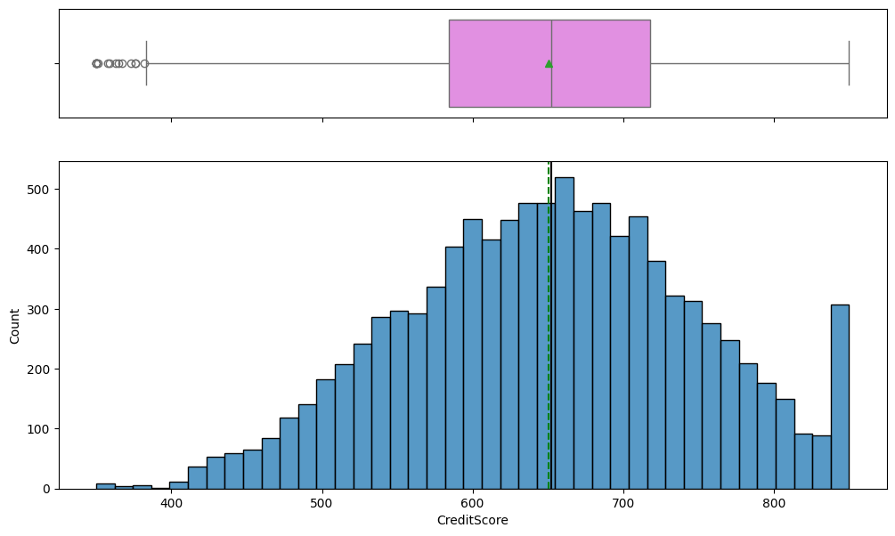

```python
histogram_boxplot(data,'CreditScore')
```

CreditScore is slightly left skewed with few outliers

**Observations on Age**

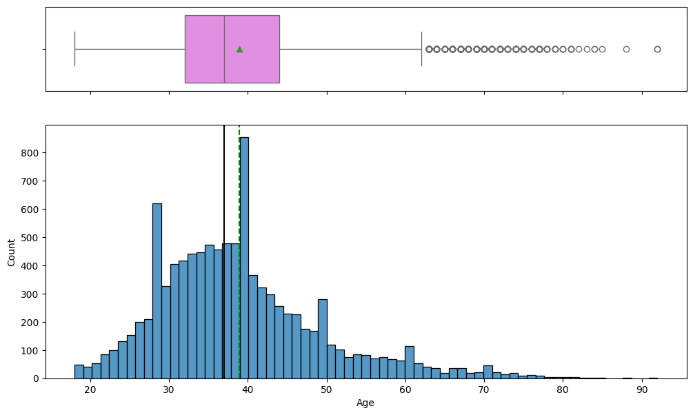

```python
histogram_boxplot(data,'Age')
```

Age feature is heavily right skewed with more outliers

**Observations on Balance**

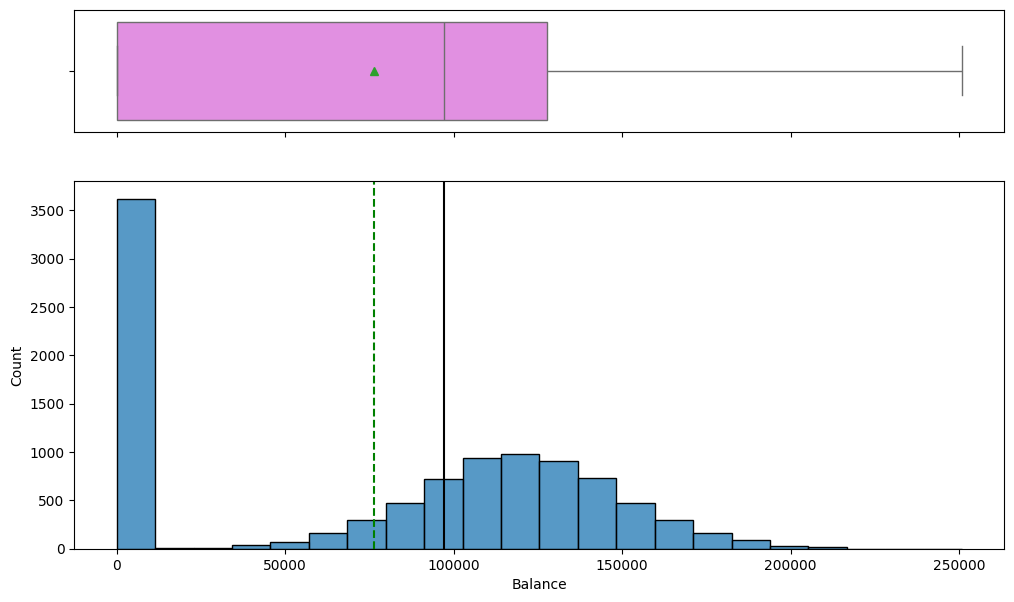

```python
histogram_boxplot(data,'Balance')
```

**Observations on Estimated Salary**

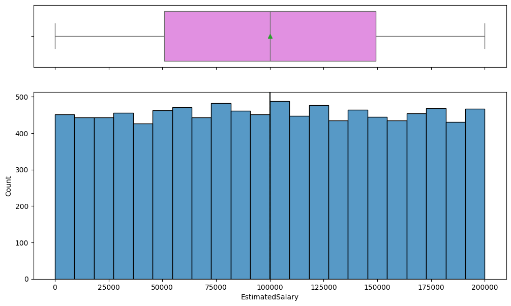

```python
histogram_boxplot(data,'EstimatedSalary')
```

**Observations on Exited**

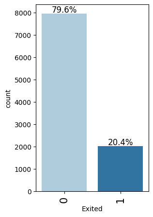

```python
labeled_barplot(data, "Exited", perc=True)
```

- 20.4% of the customers have exited from the bank

**Observations On Geography**

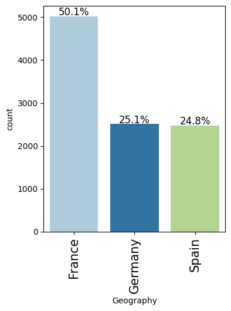

```python
labeled_barplot(data, "Geography", perc=True)
```

- 50.1 % of the customers are from France location, while 25.1% are from Germany and 24.8% of the customers are from Spain location

**Observations on Gender**

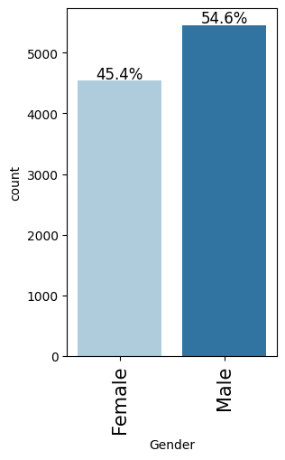

```python
labeled_barplot(data, "Gender", perc=True)
```

- 45.4% of the customers are Females and 54.6% of the customers are Males.

**Observations on Tenure**

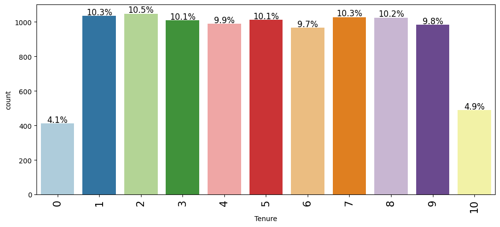

```python
labeled_barplot(data, "Tenure", perc=True)
```

- Highest Number of Customers i.e., 10.5% are with the bank for 2 years

**Observations on Number of Products**

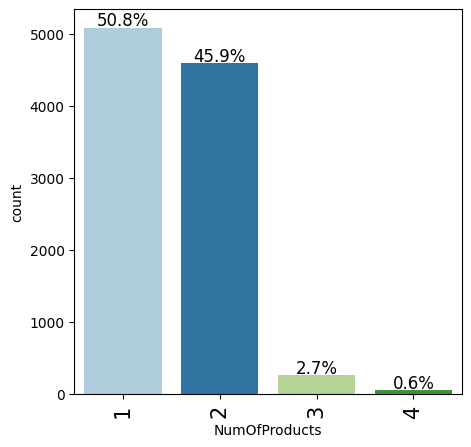

```python
labeled_barplot(data, "NumOfProducts", perc=True)
```

**Observations on Has Credit Card**

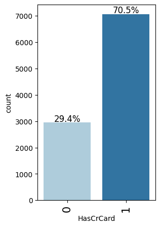

```python
labeled_barplot(data, "HasCrCard", perc=True)
```

- 70.5% of the customers have Credit Card and 29.4% of the customers doesn't have credit cards

**Observations on Is Active Member**

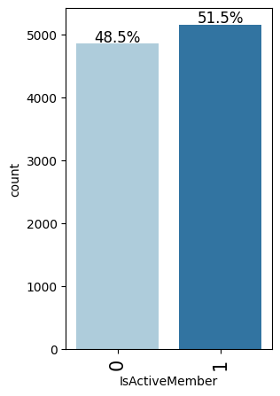

```python
labeled_barplot(data, "IsActiveMember", perc=True)
```

- 51.5% of the customers are using bank products regularly

### Bivariate Analysis

```python
# function to plot stacked bar chart


def stacked_barplot(data, predictor, target):
    """
    Print the category counts and plot a stacked bar chart

    data: dataframe
    predictor: independent variable
    target: target variable
    """
    count = data[predictor].nunique()
    sorter = data[target].value_counts().index[-1]
    tab1 = pd.crosstab(data[predictor], data[target], margins=True).sort_values(
        by=sorter, ascending=False
    )
    print(tab1)
    print("-" * 120)
    tab = pd.crosstab(data[predictor], data[target], normalize="index").sort_values(
        by=sorter, ascending=False
    )
    tab.plot(kind="bar", stacked=True, figsize=(count + 1, 5))
    plt.legend(
        loc="lower left",
        frameon=False,
    )
    plt.legend(loc="upper left", bbox_to_anchor=(1, 1))
    plt.show()
```

```python
# List of Numerical Columns
cols_list = ["CreditScore","Age","Tenure","Balance","EstimatedSalary"]
```

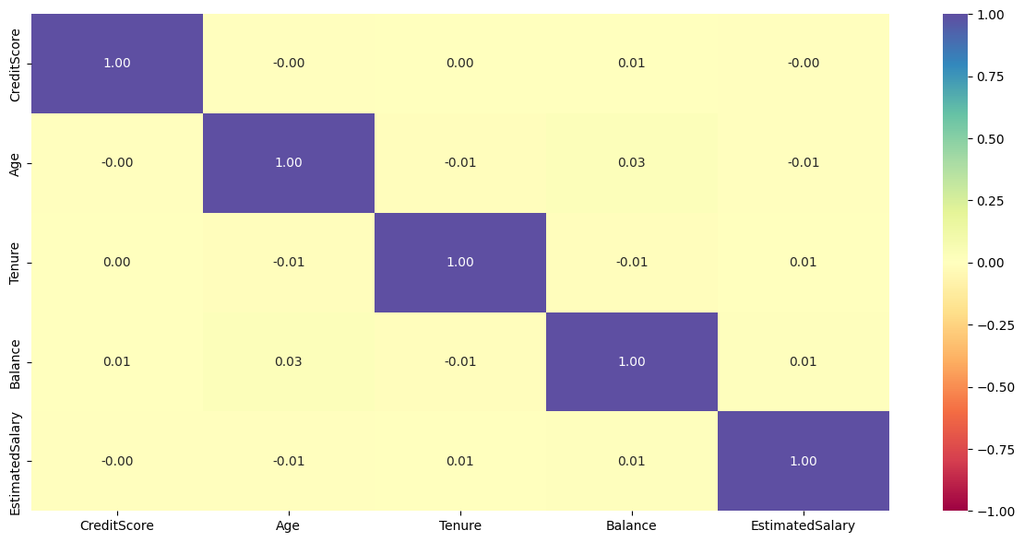

```python
plt.figure(figsize=(15, 7))
sns.heatmap(data[cols_list].corr(), annot=True, vmin=-1, vmax=1, fmt=".2f", cmap="Spectral")
plt.show()
```

From the above heatmap, We can see that there is no significant Linear relationship between the features

**Exited Vs Geography**

```
Exited        0     1    All
Geography
All        7963  2037  10000
Germany    1695   814   2509
France     4204   810   5014
Spain      2064   413   2477
------------------------------------------------------------------------------------------------------------------------
```

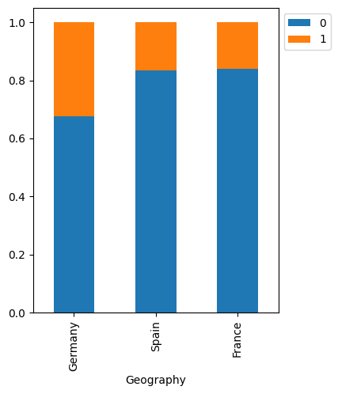

```python
stacked_barplot(data, "Geography", "Exited" )
```

- Customers from Germany location have exited more than customers from Spain & France locations

**Exited Vs Gender**

```
Exited     0     1    All
Gender
All     7963  2037  10000
Female  3404  1139   4543
Male    4559   898   5457
------------------------------------------------------------------------------------------------------------------------
```

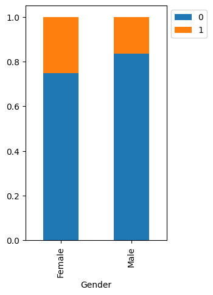

```python
stacked_barplot(data, "Gender", "Exited" )
```

- Female customers have exited more than Male Customers

**Exited Vs Has Credit Card**

```
Exited        0     1    All
HasCrCard
All        7963  2037  10000
1          5631  1424   7055
0          2332   613   2945
------------------------------------------------------------------------------------------------------------------------
```

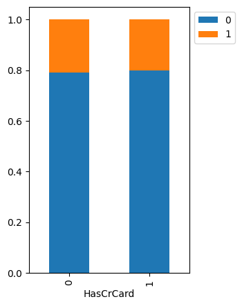

```python
stacked_barplot(data, "HasCrCard", "Exited" )
```

- HasCrCard doesn't seem to have much impact on the customers churning from the bank

**Exited Vs Is Active Member**

```
Exited             0     1    All
IsActiveMember
All             7963  2037  10000
0               3547  1302   4849
1               4416   735   5151
------------------------------------------------------------------------------------------------------------------------
```

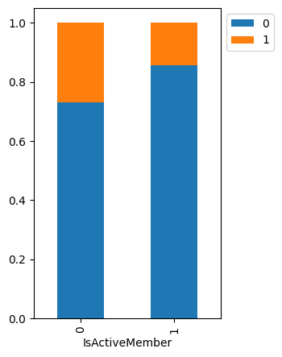

```python
stacked_barplot(data, "IsActiveMember", "Exited" )
```

- Customers who churned from the bank were not using bank products regularly (Non-Active Members)

**Exited Vs Credit Score**

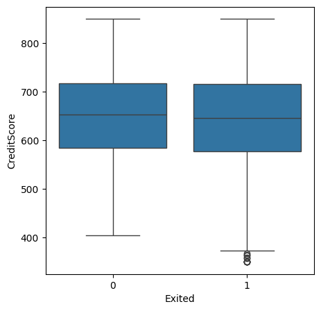

```python
plt.figure(figsize=(5,5))
sns.boxplot(y='CreditScore',x='Exited',data=data)
plt.show()
```

Avg Credit Score is almost the same for Active and Churned customers

**Exited Vs Age**

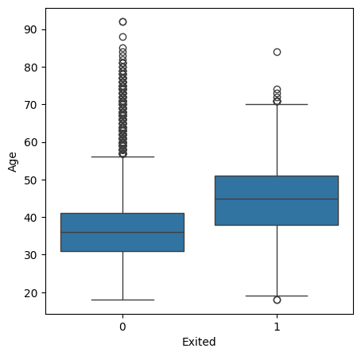

```python
plt.figure(figsize=(5,5))
sns.boxplot(y='Age',x='Exited',data=data)
plt.show()
```

- From these we could see most of the people who have churned from the bank are older people

**Exited Vs Tenure**

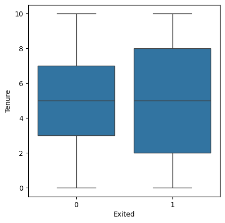

```python
plt.figure(figsize=(5,5))
sns.boxplot(y='Tenure',x='Exited',data=data)
plt.show()
```

**Exited Vs Balance**

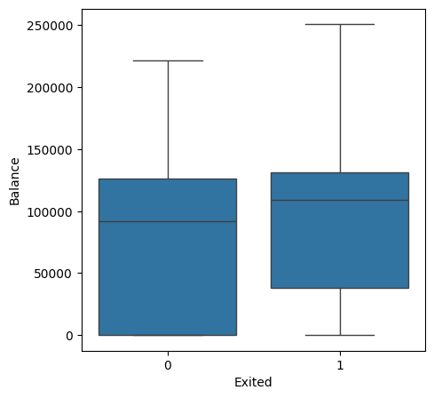

```python
plt.figure(figsize=(5,5))
sns.boxplot(y='Balance',x='Exited',data=data)
plt.show()
```

- Average bank balance of the churned customers is high

**Exited Vs Number of Products**

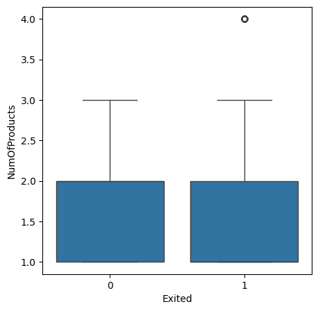

```python
plt.figure(figsize=(5,5))
sns.boxplot(y='NumOfProducts',x='Exited',data=data)
plt.show()
```

- Number of Products feature doesn't seem to have much impact

**Exited Vs Estimated Salary**

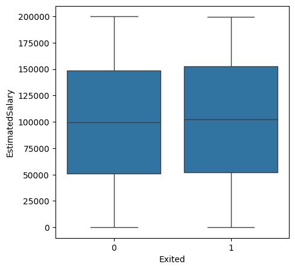

```python
plt.figure(figsize=(5,5))
sns.boxplot(y='EstimatedSalary',x='Exited',data=data)
plt.show()
```

- Average estimated salary feature also doesn't seem to have much impact

## Data Preprocessing

### Dummy Variable Creation

```python
data = pd.get_dummies(data,columns=data.select_dtypes(include=["object"]).columns.tolist(),drop_first=True,dtype=float)
```

### Train-validation-test Split

```python
X = data.drop(['Exited'],axis=1)
y = data['Exited']
```

```python
# Splitting the dataset into the Training and Testing set.

X_large, X_test, y_large, y_test = train_test_split(X, y, test_size = 0.3, random_state = 42,stratify=y,shuffle = True)
```

```python
# Splitting the dataset into the Training and Testing set.

X_train, X_val, y_train, y_val = train_test_split(X_large, y_large, test_size = 0.3, random_state = 42,stratify=y_large, shuffle = True)
```

```python
print(X_train.shape, X_val.shape, X_test.shape)
```

```
(4900, 11) (2100, 11) (3000, 11)
```

- Train data has 4900 rows while validation has 2100 rows and test has 3000 rows

```python
print(y_train.shape, y_val.shape, y_test.shape)
```

```
(4900,) (2100,) (3000,)
```

### Data Normalization

Let's scale all the numerical values to bring on to the same scale

```python
# creating an instance of the standard scaler
sc = StandardScaler()

X_train[cols_list] = sc.fit_transform(X_train[cols_list])
X_val[cols_list] = sc.transform(X_val[cols_list])
X_test[cols_list] = sc.transform(X_test[cols_list])
```

## Model Building

### Model Evaluation Criterion

Write down the logic for choosing the metric that would be the best metric for this business scenario.

-

**The model can make incorrect predictions in two ways:**

Predicting that a customer is leaving when they are actually staying (False Positive). Predicting that a customer is staying when they are actually leaving (False Negative).

**Which case is more critical?**

The second case, predicting that a customer will stay but they are actually leaving (False Negative), is more concerning. This can lead to significant financial losses for the bank because, due to the misidentification, the bank may miss opportunities to engage with and retain these at-risk customers.

**How can this loss be reduced (i.e., how to minimize False Negatives)?**

To reduce False Negatives, the bank should prioritize improving Recall. A higher Recall reduces the likelihood of missing customers who are about to leave. Therefore, the focus should be on increasing Recall by accurately identifying True Positives (i.e., customers who are indeed planning to leave), which allows the bank to take proactive measures to retain them.

**Function for plotting the confusion matrix**

```python
def make_confusion_matrix(actual_targets, predicted_targets):
    """
    To plot the confusion_matrix with percentages

    actual_targets: actual target (dependent) variable values
    predicted_targets: predicted target (dependent) variable values
    """
    cm = confusion_matrix(actual_targets, predicted_targets)
    labels = np.asarray(
        [
            ["{0:0.0f}".format(item) + "\n{0:.2%}".format(item / cm.flatten().sum())]
            for item in cm.flatten()
        ]
    ).reshape(cm.shape[0], cm.shape[1])

    plt.figure(figsize=(6, 4))
    sns.heatmap(cm, annot=labels, fmt="")
    plt.ylabel("True label")
    plt.xlabel("Predicted label")
```

Let's create two blank dataframes to store the recall outcomes of all the models we build

```python
train_metric_df = pd.DataFrame(columns=["recall"])
valid_metric_df = pd.DataFrame(columns=["recall"])
```

### Neural Network with SGD Optimizer

```python
backend.clear_session()
#Fixing the seed for random number generators ensures that we get the same output every time.
np.random.seed(2)
random.seed(2)
tf.random.set_seed(2)
```

```python
#Initializing the neural network
model_0 = Sequential()
# Adding the input layer with 64 neurons and relu as activation function
model_0.add(Dense(64, activation='relu', input_dim = X_train.shape[1]))
#Adding 1st hidden layer with 32 neurons
model_0.add(Dense(32, activation='relu'))
# Let's add output layer and since the output of the prediction is either 1 or 0 , we will go ahead and use Sigmoid activation function in the output layer
model_0.add(Dense(1, activation = 'sigmoid'))
```

```python
optimizer = tf.keras.optimizers.SGD(0.001)

# Let's use Recall as a metric in this case
metric = keras.metrics.Recall()
```

```python
# Let's compile the model with SGD optimizer and binary cross entropy as loss with recall as metrics
model_0.compile(loss='binary_crossentropy',optimizer=optimizer,metrics=[metric])
```

```python
model_0.summary()
```

```
Model: "sequential"
```

```
┏━━━━━━━━━━━━━━━━━━━━━━━━━━━━━━━━━━━━━━┳━━━━━━━━━━━━━━━━━━━━━━━━━━━━━┳━━━━━━━━━━━━━━━━━┓
┃ Layer (type)                         ┃ Output Shape                ┃         Param # ┃
┡━━━━━━━━━━━━━━━━━━━━━━━━━━━━━━━━━━━━━━╇━━━━━━━━━━━━━━━━━━━━━━━━━━━━━╇━━━━━━━━━━━━━━━━━┩
│ dense (Dense)                        │ (None, 64)                  │             768 │
├──────────────────────────────────────┼─────────────────────────────┼─────────────────┤
│ dense_1 (Dense)                      │ (None, 32)                  │           2,080 │
├──────────────────────────────────────┼─────────────────────────────┼─────────────────┤
│ dense_2 (Dense)                      │ (None, 1)                   │              33 │
└──────────────────────────────────────┴─────────────────────────────┴─────────────────┘
```

```
 Total params: 2,881 (11.25 KB)
```

```
 Trainable params: 2,881 (11.25 KB)
```

```
 Non-trainable params: 0 (0.00 B)
```

```python
# Fitting the ANN with 32 as batch size and 100 epochs

history_0 = model_0.fit(
    X_train, y_train,
    batch_size=32,
    validation_data=(X_val,y_val),
    epochs=100,
    verbose=1
)
```

```
154/154 ━━━━━━━━━━━━━━━━━━━━ 1s 4ms/step - loss: 0.6348 - recall: 0.1477 - val_loss: 0.5956 - val_recall: 0.0117
154/154 ━━━━━━━━━━━━━━━━━━━━ 0s 3ms/step - loss: 0.5809 - recall: 0.0195 - val_loss: 0.5604 - val_recall: 0.0023
154/154 ━━━━━━━━━━━━━━━━━━━━ 1s 3ms/step - loss: 0.5490 - recall: 0.0000e+00 - val_loss: 0.5388 - val_recall: 0.0000e+00
154/154 ━━━━━━━━━━━━━━━━━━━━ 1s 3ms/step - loss: 0.5292 - recall: 0.0000e+00 - val_loss: 0.5251 - val_recall: 0.0000e+00
154/154 ━━━━━━━━━━━━━━━━━━━━ 0s 2ms/step - loss: 0.5165 - recall: 0.0000e+00 - val_loss: 0.5160 - val_recall: 0.0000e+00
154/154 ━━━━━━━━━━━━━━━━━━━━ 0s 3ms/step - loss: 0.5080 - recall: 0.0000e+00 - val_loss: 0.5095 - val_recall: 0.0000e+00
154/154 ━━━━━━━━━━━━━━━━━━━━ 1s 2ms/step - loss: 0.5020 - recall: 0.0000e+00 - val_loss: 0.5047 - val_recall: 0.0000e+00
154/154 ━━━━━━━━━━━━━━━━━━━━ 1s 4ms/step - loss: 0.4975 - recall: 0.0000e+00 - val_loss: 0.5008 - val_recall: 0.0000e+00
154/154 ━━━━━━━━━━━━━━━━━━━━ 1s 3ms/step - loss: 0.4938 - recall: 0.0000e+00 - val_loss: 0.4975 - val_recall: 0.0000e+00
154/154 ━━━━━━━━━━━━━━━━━━━━ 1s 3ms/step - loss: 0.4908 - recall: 0.0000e+00 - val_loss: 0.4946 - val_recall: 0.0000e+00
154/154 ━━━━━━━━━━━━━━━━━━━━ 1s 4ms/step - loss: 0.4881 - recall: 0.0000e+00 - val_loss: 0.4919 - val_recall: 0.0000e+00
154/154 ━━━━━━━━━━━━━━━━━━━━ 1s 3ms/step - loss: 0.4856 - recall: 0.0000e+00 - val_loss: 0.4894 - val_recall: 0.0000e+00
154/154 ━━━━━━━━━━━━━━━━━━━━ 1s 3ms/step - loss: 0.4834 - recall: 0.0000e+00 - val_loss: 0.4871 - val_recall: 0.0000e+00
154/154 ━━━━━━━━━━━━━━━━━━━━ 1s 2ms/step - loss: 0.4813 - recall: 0.0000e+00 - val_loss: 0.4849 - val_recall: 0.0000e+00
154/154 ━━━━━━━━━━━━━━━━━━━━ 1s 2ms/step - loss: 0.4794 - recall: 0.0000e+00 - val_loss: 0.4829 - val_recall: 0.0000e+00
154/154 ━━━━━━━━━━━━━━━━━━━━ 1s 2ms/step - loss: 0.4776 - recall: 0.0000e+00 - val_loss: 0.4809 - val_recall: 0.0000e+00
154/154 ━━━━━━━━━━━━━━━━━━━━ 1s 2ms/step - loss: 0.4758 - recall: 0.0000e+00 - val_loss: 0.4790 - val_recall: 0.0000e+00
154/154 ━━━━━━━━━━━━━━━━━━━━ 1s 2ms/step - loss: 0.4742 - recall: 0.0000e+00 - val_loss: 0.4771 - val_recall: 0.0000e+00
154/154 ━━━━━━━━━━━━━━━━━━━━ 1s 3ms/step - loss: 0.4726 - recall: 0.0000e+00 - val_loss: 0.4754 - val_recall: 0.0000e+00
154/154 ━━━━━━━━━━━━━━━━━━━━ 1s 3ms/step - loss: 0.4711 - recall: 0.0000e+00 - val_loss: 0.4737 - val_recall: 0.0000e+00
154/154 ━━━━━━━━━━━━━━━━━━━━ 1s 3ms/step - loss: 0.4697 - recall: 0.0000e+00 - val_loss: 0.4721 - val_recall: 0.0000e+00
154/154 ━━━━━━━━━━━━━━━━━━━━ 1s 3ms/step - loss: 0.4684 - recall: 2.8515e-04 - val_loss: 0.4705 - val_recall: 0.0000e+00
154/154 ━━━━━━━━━━━━━━━━━━━━ 0s 2ms/step - loss: 0.4670 - recall: 2.8515e-04 - val_loss: 0.4690 - val_recall: 0.0000e+00
154/154 ━━━━━━━━━━━━━━━━━━━━ 1s 3ms/step - loss: 0.4658 - recall: 2.8515e-04 - val_loss: 0.4675 - val_recall: 0.0000e+00
154/154 ━━━━━━━━━━━━━━━━━━━━ 1s 2ms/step - loss: 0.4646 - recall: 2.8515e-04 - val_loss: 0.4661 - val_recall: 0.0000e+00
154/154 ━━━━━━━━━━━━━━━━━━━━ 1s 3ms/step - loss: 0.4634 - recall: 2.8515e-04 - val_loss: 0.4648 - val_recall: 0.0023
154/154 ━━━━━━━━━━━━━━━━━━━━ 1s 2ms/step - loss: 0.4623 - recall: 2.8515e-04 - val_loss: 0.4635 - val_recall: 0.0023
154/154 ━━━━━━━━━━━━━━━━━━━━ 1s 2ms/step - loss: 0.4612 - recall: 2.8515e-04 - val_loss: 0.4622 - val_recall: 0.0023
154/154 ━━━━━━━━━━━━━━━━━━━━ 1s 4ms/step - loss: 0.4602 - recall: 2.8515e-04 - val_loss: 0.4610 - val_recall: 0.0070
154/154 ━━━━━━━━━━━━━━━━━━━━ 1s 3ms/step - loss: 0.4592 - recall: 2.8515e-04 - val_loss: 0.4598 - val_recall: 0.0070
154/154 ━━━━━━━━━━━━━━━━━━━━ 1s 4ms/step - loss: 0.4583 - recall: 2.8515e-04 - val_loss: 0.4587 - val_recall: 0.0070
154/154 ━━━━━━━━━━━━━━━━━━━━ 1s 4ms/step - loss: 0.4574 - recall: 0.0023 - val_loss: 0.4576 - val_recall: 0.0070
154/154 ━━━━━━━━━━━━━━━━━━━━ 1s 4ms/step - loss: 0.4565 - recall: 0.0044 - val_loss: 0.4565 - val_recall: 0.0070
154/154 ━━━━━━━━━━━━━━━━━━━━ 1s 2ms/step - loss: 0.4556 - recall: 0.0084 - val_loss: 0.4555 - val_recall: 0.0093
154/154 ━━━━━━━━━━━━━━━━━━━━ 1s 2ms/step - loss: 0.4548 - recall: 0.0125 - val_loss: 0.4545 - val_recall: 0.0117
154/154 ━━━━━━━━━━━━━━━━━━━━ 0s 3ms/step - loss: 0.4540 - recall: 0.0215 - val_loss: 0.4536 - val_recall: 0.0117
154/154 ━━━━━━━━━━━━━━━━━━━━ 1s 3ms/step - loss: 0.4532 - recall: 0.0224 - val_loss: 0.4526 - val_recall: 0.0164
154/154 ━━━━━━━━━━━━━━━━━━━━ 0s 2ms/step - loss: 0.4525 - recall: 0.0311 - val_loss: 0.4517 - val_recall: 0.0187
154/154 ━━━━━━━━━━━━━━━━━━━━ 1s 2ms/step - loss: 0.4518 - recall: 0.0311 - val_loss: 0.4509 - val_recall: 0.0187
154/154 ━━━━━━━━━━━━━━━━━━━━ 1s 2ms/step - loss: 0.4511 - recall: 0.0316 - val_loss: 0.4500 - val_recall: 0.0210
```

[output cut: 45 more lines]

```
154/154 ━━━━━━━━━━━━━━━━━━━━ 1s 3ms/step - loss: 0.4341 - recall: 0.1447 - val_loss: 0.4287 - val_recall: 0.1238
154/154 ━━━━━━━━━━━━━━━━━━━━ 1s 3ms/step - loss: 0.4339 - recall: 0.1478 - val_loss: 0.4284 - val_recall: 0.1262
154/154 ━━━━━━━━━━━━━━━━━━━━ 1s 4ms/step - loss: 0.4337 - recall: 0.1503 - val_loss: 0.4282 - val_recall: 0.1285
154/154 ━━━━━━━━━━━━━━━━━━━━ 1s 5ms/step - loss: 0.4334 - recall: 0.1508 - val_loss: 0.4279 - val_recall: 0.1285
154/154 ━━━━━━━━━━━━━━━━━━━━ 1s 4ms/step - loss: 0.4332 - recall: 0.1545 - val_loss: 0.4276 - val_recall: 0.1285
154/154 ━━━━━━━━━━━━━━━━━━━━ 1s 4ms/step - loss: 0.4330 - recall: 0.1579 - val_loss: 0.4274 - val_recall: 0.1308
154/154 ━━━━━━━━━━━━━━━━━━━━ 0s 3ms/step - loss: 0.4328 - recall: 0.1579 - val_loss: 0.4272 - val_recall: 0.1308
154/154 ━━━━━━━━━━━━━━━━━━━━ 1s 3ms/step - loss: 0.4326 - recall: 0.1592 - val_loss: 0.4269 - val_recall: 0.1308
154/154 ━━━━━━━━━━━━━━━━━━━━ 0s 3ms/step - loss: 0.4323 - recall: 0.1637 - val_loss: 0.4267 - val_recall: 0.1355
154/154 ━━━━━━━━━━━━━━━━━━━━ 1s 2ms/step - loss: 0.4321 - recall: 0.1637 - val_loss: 0.4264 - val_recall: 0.1379
154/154 ━━━━━━━━━━━━━━━━━━━━ 1s 3ms/step - loss: 0.4319 - recall: 0.1640 - val_loss: 0.4262 - val_recall: 0.1379
154/154 ━━━━━━━━━━━━━━━━━━━━ 0s 3ms/step - loss: 0.4317 - recall: 0.1652 - val_loss: 0.4260 - val_recall: 0.1379
154/154 ━━━━━━━━━━━━━━━━━━━━ 1s 3ms/step - loss: 0.4315 - recall: 0.1660 - val_loss: 0.4257 - val_recall: 0.1402
154/154 ━━━━━━━━━━━━━━━━━━━━ 0s 3ms/step - loss: 0.4313 - recall: 0.1670 - val_loss: 0.4255 - val_recall: 0.1402
154/154 ━━━━━━━━━━━━━━━━━━━━ 1s 3ms/step - loss: 0.4311 - recall: 0.1705 - val_loss: 0.4253 - val_recall: 0.1425
```

**Loss Function**

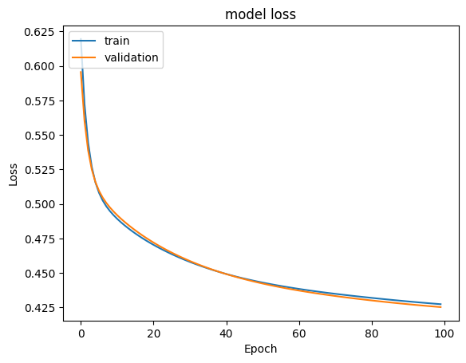

```python
#Plotting Train Loss vs Validation Loss
plt.plot(history_0.history['loss'])
plt.plot(history_0.history['val_loss'])
plt.title('model loss')
plt.ylabel('Loss')
plt.xlabel('Epoch')
plt.legend(['train', 'validation'], loc='upper left')
plt.show()
```

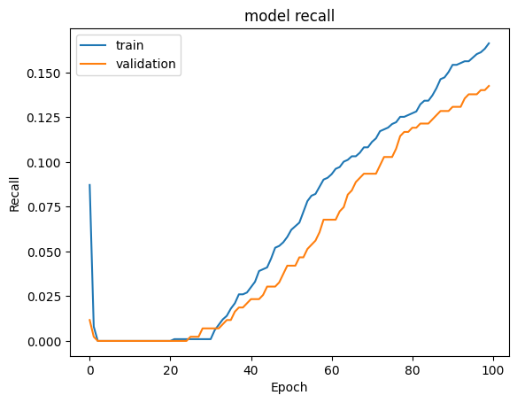

```python
#Plotting Train recall vs Validation recall
plt.plot(history_0.history['recall'])
plt.plot(history_0.history['val_recall'])
plt.title('model recall')
plt.ylabel('Recall')
plt.xlabel('Epoch')
plt.legend(['train', 'validation'], loc='upper left')
plt.show()
```

```python
#Predicting the results using best as a threshold
y_train_pred = model_0.predict(X_train)
y_train_pred = (y_train_pred > 0.5)
y_train_pred
```

```
154/154 ━━━━━━━━━━━━━━━━━━━━ 0s 2ms/step
```

```
array([[False],
       [False],
       [False],
       ...,
       [False],
       [False],
       [False]])
```

```python
#Predicting the results using best as a threshold
y_val_pred = model_0.predict(X_val)
y_val_pred = (y_val_pred > 0.5)
y_val_pred
```

```
66/66 ━━━━━━━━━━━━━━━━━━━━ 0s 1ms/step
```

```
array([[False],
       [False],
       [False],
       ...,
       [False],
       [False],
       [False]])
```

```python
model_name = "Neural Network with SGD"

train_metric_df.loc[model_name] = recall_score(y_train, y_train_pred)
valid_metric_df.loc[model_name] = recall_score(y_val, y_val_pred)
```

**Classification Report**

```python
#Classification report
cr = classification_report(y_train, y_train_pred)
print(cr)
```

```
              precision    recall  f1-score   support

           0       0.82      0.98      0.89      3902
           1       0.68      0.17      0.27       998

    accuracy                           0.81      4900
   macro avg       0.75      0.57      0.58      4900
weighted avg       0.79      0.81      0.77      4900
```

```python
#Classification report on validation set
cr = classification_report(y_val, y_val_pred)
print(cr)
```

```
              precision    recall  f1-score   support

           0       0.82      0.97      0.89      1672
           1       0.55      0.14      0.23       428

    accuracy                           0.80      2100
   macro avg       0.69      0.56      0.56      2100
weighted avg       0.76      0.80      0.75      2100
```

**Confusion Matrix**

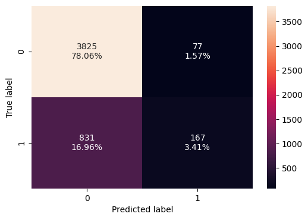

```python
make_confusion_matrix(y_train, y_train_pred)
```

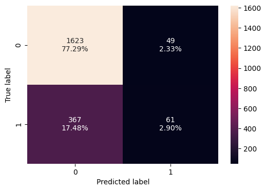

```python
make_confusion_matrix(y_val, y_val_pred)
```

The model performs well on class 0 (majority class) with high precision, recall, and F1-score. However, performance on class 1 (minority class) is poor, especially in terms of recall (only 17% of actual class 1 instances are identified in training set and only 14% of actual class 1 instances are identified in validation set), leading to a low F1-score. The model likely needs improvement in handling the minority class (class 1).

## Model Performance Improvement

### Neural Network with Adam Optimizer

```python
backend.clear_session()
#Fixing the seed for random number generators so that we can ensure we receive the same output everytime
np.random.seed(2)
random.seed(2)
tf.random.set_seed(2)
```

```python
#Initializing the neural network
model_1 = Sequential()
#Adding the input layer with 64 neurons and relu as activation function
model_1.add(Dense(64,activation='relu',input_dim = X_train.shape[1]))
#Adding the first hidden layer with 32 neurons with relu as activation functions
model_1.add(Dense(32,activation='relu'))
# Adding the output layer
model_1.add(Dense(1, activation = 'sigmoid'))
```

```python
optimizer = tf.keras.optimizers.Adam(0.001)
metric = keras.metrics.Recall()
```

```python
#Let's compile the model with binary cross entropy as loss function and recall as the metric
model_1.compile(loss='binary_crossentropy',optimizer=optimizer,metrics=[metric])
```

```python
model_1.summary()
```

```
Model: "sequential"
```

```
┏━━━━━━━━━━━━━━━━━━━━━━━━━━━━━━━━━━━━━━┳━━━━━━━━━━━━━━━━━━━━━━━━━━━━━┳━━━━━━━━━━━━━━━━━┓
┃ Layer (type)                         ┃ Output Shape                ┃         Param # ┃
┡━━━━━━━━━━━━━━━━━━━━━━━━━━━━━━━━━━━━━━╇━━━━━━━━━━━━━━━━━━━━━━━━━━━━━╇━━━━━━━━━━━━━━━━━┩
│ dense (Dense)                        │ (None, 64)                  │             768 │
├──────────────────────────────────────┼─────────────────────────────┼─────────────────┤
│ dense_1 (Dense)                      │ (None, 32)                  │           2,080 │
├──────────────────────────────────────┼─────────────────────────────┼─────────────────┤
│ dense_2 (Dense)                      │ (None, 1)                   │              33 │
└──────────────────────────────────────┴─────────────────────────────┴─────────────────┘
```

```
 Total params: 2,881 (11.25 KB)
```

```
 Trainable params: 2,881 (11.25 KB)
```

```
 Non-trainable params: 0 (0.00 B)
```

```python
#Fitting the ANN with batch size as 32 and epochs as 100
history_1 = model_1.fit(
    X_train,y_train,
    batch_size=32,
    validation_data=(X_val,y_val),
    epochs=100,
    verbose=1
)
```

```
154/154 ━━━━━━━━━━━━━━━━━━━━ 4s 4ms/step - loss: 0.5095 - recall: 0.0334 - val_loss: 0.4280 - val_recall: 0.1822
154/154 ━━━━━━━━━━━━━━━━━━━━ 1s 4ms/step - loss: 0.4324 - recall: 0.1784 - val_loss: 0.4154 - val_recall: 0.2874
154/154 ━━━━━━━━━━━━━━━━━━━━ 1s 5ms/step - loss: 0.4197 - recall: 0.2332 - val_loss: 0.4061 - val_recall: 0.3224
154/154 ━━━━━━━━━━━━━━━━━━━━ 1s 4ms/step - loss: 0.4097 - recall: 0.2678 - val_loss: 0.3989 - val_recall: 0.3481
154/154 ━━━━━━━━━━━━━━━━━━━━ 1s 5ms/step - loss: 0.4005 - recall: 0.3096 - val_loss: 0.3926 - val_recall: 0.3715
154/154 ━━━━━━━━━━━━━━━━━━━━ 1s 5ms/step - loss: 0.3925 - recall: 0.3244 - val_loss: 0.3870 - val_recall: 0.3902
154/154 ━━━━━━━━━━━━━━━━━━━━ 1s 3ms/step - loss: 0.3850 - recall: 0.3383 - val_loss: 0.3824 - val_recall: 0.4112
154/154 ━━━━━━━━━━━━━━━━━━━━ 1s 3ms/step - loss: 0.3782 - recall: 0.3610 - val_loss: 0.3785 - val_recall: 0.4182
154/154 ━━━━━━━━━━━━━━━━━━━━ 1s 3ms/step - loss: 0.3719 - recall: 0.3643 - val_loss: 0.3749 - val_recall: 0.4322
154/154 ━━━━━━━━━━━━━━━━━━━━ 1s 3ms/step - loss: 0.3661 - recall: 0.3731 - val_loss: 0.3719 - val_recall: 0.4416
154/154 ━━━━━━━━━━━━━━━━━━━━ 1s 3ms/step - loss: 0.3607 - recall: 0.3827 - val_loss: 0.3696 - val_recall: 0.4486
154/154 ━━━━━━━━━━━━━━━━━━━━ 1s 3ms/step - loss: 0.3557 - recall: 0.3960 - val_loss: 0.3675 - val_recall: 0.4556
154/154 ━━━━━━━━━━━━━━━━━━━━ 0s 3ms/step - loss: 0.3511 - recall: 0.4122 - val_loss: 0.3652 - val_recall: 0.4650
154/154 ━━━━━━━━━━━━━━━━━━━━ 0s 3ms/step - loss: 0.3467 - recall: 0.4206 - val_loss: 0.3632 - val_recall: 0.4650
154/154 ━━━━━━━━━━━━━━━━━━━━ 1s 3ms/step - loss: 0.3430 - recall: 0.4302 - val_loss: 0.3618 - val_recall: 0.4696
154/154 ━━━━━━━━━━━━━━━━━━━━ 1s 3ms/step - loss: 0.3397 - recall: 0.4392 - val_loss: 0.3605 - val_recall: 0.4743
154/154 ━━━━━━━━━━━━━━━━━━━━ 1s 3ms/step - loss: 0.3365 - recall: 0.4480 - val_loss: 0.3597 - val_recall: 0.4766
154/154 ━━━━━━━━━━━━━━━━━━━━ 1s 8ms/step - loss: 0.3335 - recall: 0.4533 - val_loss: 0.3592 - val_recall: 0.4790
154/154 ━━━━━━━━━━━━━━━━━━━━ 1s 3ms/step - loss: 0.3308 - recall: 0.4538 - val_loss: 0.3591 - val_recall: 0.4790
154/154 ━━━━━━━━━━━━━━━━━━━━ 1s 3ms/step - loss: 0.3282 - recall: 0.4615 - val_loss: 0.3588 - val_recall: 0.4907
154/154 ━━━━━━━━━━━━━━━━━━━━ 1s 3ms/step - loss: 0.3258 - recall: 0.4670 - val_loss: 0.3591 - val_recall: 0.4977
154/154 ━━━━━━━━━━━━━━━━━━━━ 1s 5ms/step - loss: 0.3237 - recall: 0.4680 - val_loss: 0.3589 - val_recall: 0.5000
154/154 ━━━━━━━━━━━━━━━━━━━━ 1s 5ms/step - loss: 0.3215 - recall: 0.4670 - val_loss: 0.3590 - val_recall: 0.5047
154/154 ━━━━━━━━━━━━━━━━━━━━ 1s 6ms/step - loss: 0.3197 - recall: 0.4734 - val_loss: 0.3595 - val_recall: 0.5070
154/154 ━━━━━━━━━━━━━━━━━━━━ 1s 5ms/step - loss: 0.3179 - recall: 0.4728 - val_loss: 0.3598 - val_recall: 0.5070
154/154 ━━━━━━━━━━━━━━━━━━━━ 1s 3ms/step - loss: 0.3162 - recall: 0.4750 - val_loss: 0.3603 - val_recall: 0.5047
154/154 ━━━━━━━━━━━━━━━━━━━━ 1s 3ms/step - loss: 0.3145 - recall: 0.4820 - val_loss: 0.3606 - val_recall: 0.5070
154/154 ━━━━━━━━━━━━━━━━━━━━ 1s 3ms/step - loss: 0.3130 - recall: 0.4836 - val_loss: 0.3608 - val_recall: 0.5070
154/154 ━━━━━━━━━━━━━━━━━━━━ 1s 3ms/step - loss: 0.3114 - recall: 0.4876 - val_loss: 0.3613 - val_recall: 0.5117
154/154 ━━━━━━━━━━━━━━━━━━━━ 0s 2ms/step - loss: 0.3098 - recall: 0.4917 - val_loss: 0.3619 - val_recall: 0.5164
154/154 ━━━━━━━━━━━━━━━━━━━━ 1s 3ms/step - loss: 0.3082 - recall: 0.4919 - val_loss: 0.3625 - val_recall: 0.5164
154/154 ━━━━━━━━━━━━━━━━━━━━ 0s 3ms/step - loss: 0.3067 - recall: 0.5000 - val_loss: 0.3629 - val_recall: 0.5140
154/154 ━━━━━━━━━━━━━━━━━━━━ 1s 3ms/step - loss: 0.3052 - recall: 0.5061 - val_loss: 0.3635 - val_recall: 0.5164
154/154 ━━━━━━━━━━━━━━━━━━━━ 1s 3ms/step - loss: 0.3038 - recall: 0.5084 - val_loss: 0.3640 - val_recall: 0.5140
154/154 ━━━━━━━━━━━━━━━━━━━━ 1s 3ms/step - loss: 0.3025 - recall: 0.5112 - val_loss: 0.3647 - val_recall: 0.5187
154/154 ━━━━━━━━━━━━━━━━━━━━ 1s 3ms/step - loss: 0.3011 - recall: 0.5148 - val_loss: 0.3654 - val_recall: 0.5187
154/154 ━━━━━━━━━━━━━━━━━━━━ 1s 3ms/step - loss: 0.2999 - recall: 0.5077 - val_loss: 0.3662 - val_recall: 0.5187
154/154 ━━━━━━━━━━━━━━━━━━━━ 1s 3ms/step - loss: 0.2985 - recall: 0.5143 - val_loss: 0.3667 - val_recall: 0.5187
154/154 ━━━━━━━━━━━━━━━━━━━━ 1s 3ms/step - loss: 0.2973 - recall: 0.5150 - val_loss: 0.3671 - val_recall: 0.5210
154/154 ━━━━━━━━━━━━━━━━━━━━ 1s 3ms/step - loss: 0.2961 - recall: 0.5183 - val_loss: 0.3681 - val_recall: 0.5234
```

[output cut: 45 more lines]

```
154/154 ━━━━━━━━━━━━━━━━━━━━ 1s 3ms/step - loss: 0.2463 - recall: 0.6174 - val_loss: 0.4066 - val_recall: 0.5444
154/154 ━━━━━━━━━━━━━━━━━━━━ 1s 3ms/step - loss: 0.2455 - recall: 0.6234 - val_loss: 0.4076 - val_recall: 0.5467
154/154 ━━━━━━━━━━━━━━━━━━━━ 1s 3ms/step - loss: 0.2448 - recall: 0.6234 - val_loss: 0.4082 - val_recall: 0.5421
154/154 ━━━━━━━━━━━━━━━━━━━━ 1s 2ms/step - loss: 0.2440 - recall: 0.6269 - val_loss: 0.4101 - val_recall: 0.5444
154/154 ━━━━━━━━━━━━━━━━━━━━ 1s 3ms/step - loss: 0.2431 - recall: 0.6297 - val_loss: 0.4103 - val_recall: 0.5421
154/154 ━━━━━━━━━━━━━━━━━━━━ 1s 3ms/step - loss: 0.2420 - recall: 0.6266 - val_loss: 0.4118 - val_recall: 0.5397
154/154 ━━━━━━━━━━━━━━━━━━━━ 1s 2ms/step - loss: 0.2413 - recall: 0.6298 - val_loss: 0.4126 - val_recall: 0.5421
154/154 ━━━━━━━━━━━━━━━━━━━━ 1s 3ms/step - loss: 0.2406 - recall: 0.6321 - val_loss: 0.4135 - val_recall: 0.5421
154/154 ━━━━━━━━━━━━━━━━━━━━ 1s 2ms/step - loss: 0.2398 - recall: 0.6300 - val_loss: 0.4151 - val_recall: 0.5421
154/154 ━━━━━━━━━━━━━━━━━━━━ 1s 3ms/step - loss: 0.2392 - recall: 0.6336 - val_loss: 0.4161 - val_recall: 0.5397
154/154 ━━━━━━━━━━━━━━━━━━━━ 0s 3ms/step - loss: 0.2386 - recall: 0.6309 - val_loss: 0.4176 - val_recall: 0.5421
154/154 ━━━━━━━━━━━━━━━━━━━━ 1s 3ms/step - loss: 0.2375 - recall: 0.6353 - val_loss: 0.4180 - val_recall: 0.5421
154/154 ━━━━━━━━━━━━━━━━━━━━ 1s 3ms/step - loss: 0.2369 - recall: 0.6330 - val_loss: 0.4196 - val_recall: 0.5421
154/154 ━━━━━━━━━━━━━━━━━━━━ 1s 3ms/step - loss: 0.2364 - recall: 0.6360 - val_loss: 0.4206 - val_recall: 0.5421
154/154 ━━━━━━━━━━━━━━━━━━━━ 1s 3ms/step - loss: 0.2352 - recall: 0.6361 - val_loss: 0.4223 - val_recall: 0.5444
```

**Loss Function**

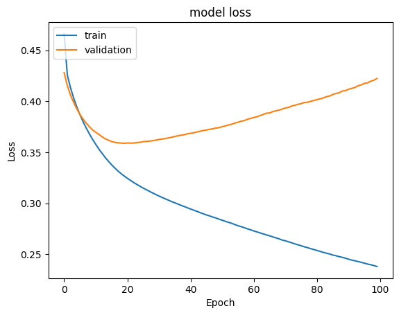

```python
#Plotting Train Loss vs Validation Loss
plt.plot(history_1.history['loss'])
plt.plot(history_1.history['val_loss'])
plt.title('model loss')
plt.ylabel('Loss')
plt.xlabel('Epoch')
plt.legend(['train', 'validation'], loc='upper left')
plt.show()
```

The model is overfitting, a common issue in deep learning due to the large number of parameters. Early stopping is an effective solution. During training, the model is evaluated on a validation set after each epoch. If performance on the validation set worsens or shows no improvement (e.g., increasing loss or decreasing accuracy), training is stopped. The model at this point is chosen for its better generalization.

This simple yet powerful method helps prevent overfitting.

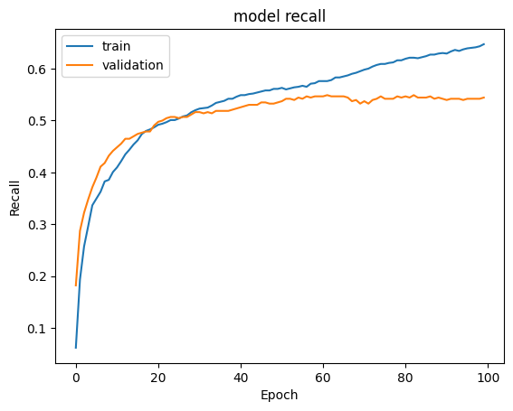

```python
#Plotting Train recall vs Validation recall
plt.plot(history_1.history['recall'])
plt.plot(history_1.history['val_recall'])
plt.title('model recall')
plt.ylabel('Recall')
plt.xlabel('Epoch')
plt.legend(['train', 'validation'], loc='upper left')
plt.show()
```

```python
#Predicting the results using 0.5 as the threshold
y_train_pred = model_1.predict(X_train)
y_train_pred = (y_train_pred > 0.5)
y_train_pred
```

```
154/154 ━━━━━━━━━━━━━━━━━━━━ 0s 2ms/step
```

```
array([[False],
       [False],
       [False],
       ...,
       [False],
       [False],
       [False]])
```

```python
#Predicting the results using 0.5 as the threshold
y_val_pred = model_1.predict(X_val)
y_val_pred = (y_val_pred > 0.5)
y_val_pred
```

```
66/66 ━━━━━━━━━━━━━━━━━━━━ 0s 1ms/step
```

```
array([[False],
       [False],
       [False],
       ...,
       [False],
       [False],
       [False]])
```

```python
model_name = "Neural Network with Adam"

train_metric_df.loc[model_name] = recall_score(y_train,y_train_pred)
valid_metric_df.loc[model_name] = recall_score(y_val,y_val_pred)
```

**Classification Report**

```python
#lassification report
cr=classification_report(y_train,y_train_pred)
print(cr)
```

```
              precision    recall  f1-score   support

           0       0.92      0.97      0.94      3902
           1       0.85      0.68      0.76       998

    accuracy                           0.91      4900
   macro avg       0.88      0.83      0.85      4900
weighted avg       0.91      0.91      0.91      4900
```

```python
#classification report
cr=classification_report(y_val,y_val_pred)
print(cr)
```

```
              precision    recall  f1-score   support

           0       0.89      0.90      0.89      1672
           1       0.59      0.54      0.57       428

    accuracy                           0.83      2100
   macro avg       0.74      0.72      0.73      2100
weighted avg       0.83      0.83      0.83      2100
```

**Training Set:** The model performs well with high precision, recall, and F1-scores for both classes, indicating good fit on the training data. **Validation Set:** The model's performance drops, particularly for Class 1, showing lower precision, recall, and F1-score. This suggests that while the model performs well on training data, it does not generalize as effectively to unseen validation data.

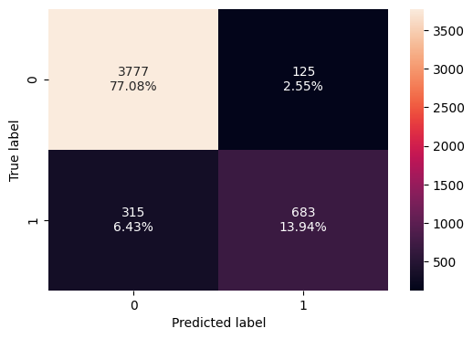

```python
#Calculating the confusion matrix
make_confusion_matrix(y_train, y_train_pred)
```

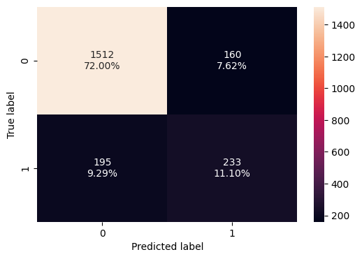

```python
#Calculating the confusion matrix
make_confusion_matrix(y_val, y_val_pred)
```